[figure not shown]

# **Instituto de Matemática Interdisciplinar.** [IMI Publica](https://ucm.es/imi/imip)

Análisis Crítico y Propuestas de Mejora del Sorteo UEFA Para la Fase Segunda de la Champions.

T. R. Basile Alvarezª, J. A. Gallegos Salgadoª.

ª Universidad Nacional Autónoma de México (UNAM).

*Boletín del IMI*, Nº 70, (1 Dic. 2022), Sección "IMI Publica".

https://doi.org/10.57037/b-imi.00070.imip

# Anexo: Código de Python

Aquí se presenta el código que hace todo el análisis necesario para obtener los resultados que se encuentran en el texto.

Primero importamos todas las librerías necesarias.

```python
import numpy as np
import matplotlib.pyplot as plt
import itertools
from scipy.optimize import minimize
!pip install birkhoff;
import birkhoff
import pandas as pd
!pip install inequalipy;
import inequalipy as ineq
```

# 1. Creamos todas las funciones y objetos necesarios

Empezamos creando una clase llamada "equipo", en la que cada elemento es un quipo campeón o subcampeón de grupo y guardamos en este objeto del que viene. Luego, introducimos los datos para la champions 2021/22 y también ponemos los datos para otras champions en clase de que querramos hacerlas después.

```python
#Creamos una clase llamada equipo, en la que cada elemento es un
#equipo campeón o subcampeón de grupo y guardamos en este objeto
# sus iniciales, el pais del que viene, su posición en el grupo y el grupo
#del que viene.

class equipo():
    def __init__(self,nombre,pais,pos,grupo):
        self.nombre = nombre
        self.pais = pais
        self.pos = pos
        self.grupo = grupo

    #Funciones para que cuando se imprima uno de estos objetos,
    #lo que se imprima sea el nombre del equipo.
    def __str__(self):
        return(self.nombre)
    def __repr__(self):
        return(self.nombre)

    # Función para comparar dos equipos y decidir si pueden jugar entre sí
    # en los 8vos de final.  Regresa el valor 1 solamente si
    # no coincide la posición, el país ni el grupo de los equipos.
    def compatibles(self,other):
        if self.pos == other.pos:
            return(0)
        if self.pais == other.pais:
            return(0)
        if self.grupo == other.grupo:
            return(0)
        return(1)

#Creamos una lista con los equipos que pasaron a 8vos de final en 2021/22.
# Ponemos los datos de cada equipo, que son: nombre, pais, posición y grupo (numerado desde el 0)
lista_equipos = []

lista_equipos.append(equipo("MCI","Inglaterra",1,0))
lista_equipos.append(equipo("LIV","Inglaterra",1,1))
lista_equipos.append(equipo("AJX","Holanda",1,2))
lista_equipos.append(equipo("RMA","España",1,3))
lista_equipos.append(equipo("BAY","Alemania",1,4))
lista_equipos.append(equipo("MUN","Inglaterra",1,5))
lista_equipos.append(equipo("LIL","Francia",1,6))
lista_equipos.append(equipo("JUV","Italia",1,7))

lista_equipos.append(equipo("PSG","Francia",2,0))
lista_equipos.append(equipo("ATM","España",2,1))
lista_equipos.append(equipo("SPO","Portugal",2,2))
lista_equipos.append(equipo("INT","Italia",2,3))
lista_equipos.append(equipo("BEN","Portugal",2,4))
lista_equipos.append(equipo("VIL","España",2,5))
lista_equipos.append(equipo("SAL","Austria",2,6))
lista_equipos.append(equipo("CHE","Inglaterra",2,7))

#### 2020: Descomentar y comentar los otros años para analizar el 2020.

# lista_equipos = []

# lista_equipos.append(equipo("BAY","Alemania",1,0))
# lista_equipos.append(equipo("RMA","España",1,1))
# lista_equipos.append(equipo("MCI","Inglaterra",1,2))
# lista_equipos.append(equipo("LIV","Inglaterra",1,3))
# lista_equipos.append(equipo("CHE","Inglaterra",1,4))
# lista_equipos.append(equipo("DOR","Alemania",1,5))
# lista_equipos.append(equipo("JUV","Italia",1,6))
# lista_equipos.append(equipo("PSG","Francia",1,7))

# lista_equipos.append(equipo("ATM","España",2,0))
# lista_equipos.append(equipo("BMO","Alemania",2,1))
# lista_equipos.append(equipo("POR","Portugal",2,2))
# lista_equipos.append(equipo("ATA","Italia",2,3))
# lista_equipos.append(equipo("SEV","España",2,4))
# lista_equipos.append(equipo("LAZ","Italia",2,5))
# lista_equipos.append(equipo("BAR","España",2,6))
# lista_equipos.append(equipo("RBL","Alemania",2,7))

#### 2019:
# lista_equipos = []

# lista_equipos.append(equipo("PSG","Francia",1,0))
# lista_equipos.append(equipo("BAY","Alemania",1,1))
# lista_equipos.append(equipo("MCI","Inglaterra",1,2))
# lista_equipos.append(equipo("JUV","Italia",1,3))
# lista_equipos.append(equipo("LIV","Inglaterra",1,4)) #
# lista_equipos.append(equipo("BAR","España",1,5))
# lista_equipos.append(equipo("RBL","Alemania",1,6))
# lista_equipos.append(equipo("VAL","España",1,7))

# lista_equipos.append(equipo("RMA","España",2,0))
# lista_equipos.append(equipo("TOT","Inglaterra",2,1))
# lista_equipos.append(equipo("ATA","Italia",2,2))
# lista_equipos.append(equipo("ATM","España",2,3))
# lista_equipos.append(equipo("NAP","Italia",2,4))
# lista_equipos.append(equipo("DOR","Alemania",2,5))
# lista_equipos.append(equipo("LYO","Francia",2,6))
# lista_equipos.append(equipo("CHE","Inglaterra",2,7))

#### 2018:
# lista_equipos = []

# lista_equipos.append(equipo("DOR","Alemania",1,0))
# lista_equipos.append(equipo("BAR","España",1,1))
# lista_equipos.append(equipo("PSG","Francia",1,2))
# lista_equipos.append(equipo("POR","Portugal",1,3))
# lista_equipos.append(equipo("BAY","Alemania",1,4)) #
# lista_equipos.append(equipo("MCI","Inglaterra",1,5))
# lista_equipos.append(equipo("RMA","España",1,6))
# lista_equipos.append(equipo("JUV","Italia",1,7))

# lista_equipos.append(equipo("ATM","España",2,0))
# lista_equipos.append(equipo("TOT","Inglaterra",2,1))
# lista_equipos.append(equipo("LIV","Inglaterra",2,2))
# lista_equipos.append(equipo("SCH","Alemania",2,3))
# lista_equipos.append(equipo("AJX","Holanda",2,4))
# lista_equipos.append(equipo("LYO","Francia",2,5))
# lista_equipos.append(equipo("ROM","Italia",2,6))
# lista_equipos.append(equipo("MUN","Inglaterra",2,7))

#### 2017:
# lista_equipos = []

# lista_equipos.append(equipo("MUN","Inglaterra",1,0))
# lista_equipos.append(equipo("PSG","Francia",1,1))
# lista_equipos.append(equipo("ROM","Italia",1,2))
# lista_equipos.append(equipo("BAR","España",1,3))
# lista_equipos.append(equipo("LIV","Inglaterra",1,4)) #
# lista_equipos.append(equipo("MCI","Inglaterra",1,5))
# lista_equipos.append(equipo("BES","Turquía",1,6))
# lista_equipos.append(equipo("TOT","Inglaterra",1,7))

# lista_equipos.append(equipo("BAS","Suiza",2,0))
# lista_equipos.append(equipo("BAY","Alemania",2,1))
# lista_equipos.append(equipo("CHE","Inglaterra",2,2))
# lista_equipos.append(equipo("JUV","Italia",2,3))
# lista_equipos.append(equipo("SEV","España",2,4))
# lista_equipos.append(equipo("SHK","Ucrania",2,5))
# lista_equipos.append(equipo("POR","Portugal",2,6))
# lista_equipos.append(equipo("RMA","España",2,7))

#### 2016:
# lista_equipos = []

# lista_equipos.append(equipo("ARS","Inglaterra",1,0))
# lista_equipos.append(equipo("NAP","Italia",1,1))
# lista_equipos.append(equipo("BAR","España",1,2))
# lista_equipos.append(equipo("ATM","España",1,3))
# lista_equipos.append(equipo("MON","Francia",1,4)) #
# lista_equipos.append(equipo("DOR","Alemania",1,5))
# lista_equipos.append(equipo("LEC","Inglaterra",1,6))
# lista_equipos.append(equipo("JUV","Italia",1,7))

# lista_equipos.append(equipo("PSG","Francia",2,0))
# lista_equipos.append(equipo("BEN","Portugal",2,1))
# lista_equipos.append(equipo("MCI","España",2,2))
# lista_equipos.append(equipo("BAY","Alemania",2,3))
# lista_equipos.append(equipo("LEV","Alemania",2,4))
# lista_equipos.append(equipo("RMA","España",2,5))
# lista_equipos.append(equipo("POR","Portugal",2,6))
# lista_equipos.append(equipo("SEV","España",2,7))
```

```python
#Creamos una lista con los equipos campeones de sus grupos

lista_campeones = []
for eq in lista_equipos:
    if eq.pos == 1:
        lista_campeones.append(eq)

#Una lista con los equipos subcampeones de sus grupos

lista_subcampeones= []
for eq in lista_equipos:
    if eq.pos == 2:
        lista_subcampeones.append(eq)
```

### Definimos algunas funciones que usaremos

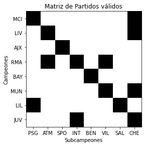

```python
def matriz_validos():
    '''Esta función crea una matriz con los campeones en las filas
    y subcamepeones en las columnas.
    La matriz vale 0 si un partido no es válido y 1 si sí.'''

    #Creamos la matriz
    mat = np.zeros((8,8))
    for i in range(8):
        for j in range(8):
            campeon = lista_campeones[i]
            subcampeon = lista_subcampeones[j]

            #Revisamos si los equipos pueden jugar entre ellos
            #ponemos un 1 si sí y un 0 si no.
            mat[i][j] = equipo.compatibles(campeon,subcampeon)
    return(mat)


def partidos_validos():
    'Función que regresa la lista de partidos que son válidos.'
    valids = matriz_validos()
    res = []
    for i in range(8):
        for j in range(8):
            if valids[i][j] ==1:
                res.append((i,j))
    return(res)

#Como prueba, graficamos la matriz de partidos válidos:
fig = plt.figure()
ax = fig.add_axes([0.1, 0.1, 0.8, 0.8])

plt.imshow(matriz_validos(),"gist_gray")
plt.xlabel("Subcampeones")
plt.ylabel("Campeones")
plt.title('Matriz de Partidos válidos')
ax.set_xticks(range(8))
ax.set_xticklabels([eq.nombre for eq in lista_subcampeones])
ax.set_yticks(range(8))
ax.set_yticklabels([eq.nombre for eq in lista_campeones])
plt.show()
```

```python
import copy


def plot_mat(mat,title="",xlabel="Subcampeones",
            ylabel="Campeones",cmap="summer",
             redondeo = 3, fontsize = 9,
             fontweight = 650, set_under = 'black',
            minimo = 1e-7):

    '''Definimos una función que sirva para
    hacer gráficas de las tablas de probabilidad.'''


    fig = plt.figure()
    ax = fig.add_axes([0.1, 0.1, 0.8, 0.8])
    cmap = copy.copy(plt.get_cmap(cmap))
    cmap.set_under(set_under)  # Valor para menor a vmin


    # Graficamos la matriz
    im = ax.imshow(mat,vmin = minimo,cmap=cmap)
    plt.xlabel(xlabel)
    plt.ylabel(ylabel)
    plt.title(title)
    ax.set_xticks(range(8))
    ax.set_xticklabels([eq.nombre for eq in lista_subcampeones])
    ax.set_yticks(range(8))
    ax.set_yticklabels([eq.nombre for eq in lista_campeones])
    plt.colorbar(im,extend='min')

    # Ponemos los números de las probabilidades
    for (j,i), label in np.ndenumerate(mat):
        ax.text(i,j,np.around(label,redondeo),ha="center",va="center",color="Black",
               fontweight=fontweight,fontsize = fontsize)

    return(im)
```

Creamos una lista llamada torneos, en la que se guardan todos los torneos (es decir, todos los posibles emparejamientos de los 16 equipos) que cumplen solamente con la primera condición (que cada partido es entre un campeón y un subcampeón).

A partir de eso, creamos una lista de torneos_validos, que son los torenos que cumplen también con las condicioens 2 y 3 (no se permiten equipos del mismgo grupo ni del mismo país)

```python
#Creamos una lista con todos los torneos posibles que se pueden formar
#Los vamos a guardar en "torneos"
torneos = []

#Vamos iterando sobre las permutaciones de 8 elementos
for p in itertools.permutations(range(8)):

    #Para cada una, creamos el torneo correspondiente
    torneo = []
    for i in range(8):
        torneo.append((i,p[i]))
    #Agregamos el torneo a la lista de torneos
    torneos.append(torneo)

#Cada torneo es una lista de 8 partidos, indicando a qué
# campeón le tocó con qué subcampeón.



def checar(torneo):
    '''Funcion para checar si un torneo es válido (es decir,
    que todos sus partidos sean válidos).'''
    for partido in torneo:
        i,j = partido
        eq1, eq2 = lista_campeones[i], lista_subcampeones[j]
        if equipo.compatibles(eq1,eq2) == 0:
            return(False)
    return(True)

#Creamos una lista solamente con los torneos válidos.
torneos_validos = []
for tor in torneos:
    if checar(tor) == True:
        torneos_validos.append(tor)


num_torneos = len(torneos_validos)
print('Cantidad de torneos válidos:', num_torneos)
print('\n Torneos:')
torneos_validos
```

```
Cantidad de torneos válidos: 4781

 Torneos:
```

```
[[(0, 1), (1, 0), (2, 3), (3, 2), (4, 5), (5, 4), (6, 7), (7, 6)],
 [(0, 1), (1, 0), (2, 3), (3, 2), (4, 5), (5, 6), (6, 7), (7, 4)],
 [(0, 1), (1, 0), (2, 3), (3, 2), (4, 6), (5, 4), (6, 7), (7, 5)],
 [(0, 1), (1, 0), (2, 3), (3, 2), (4, 7), (5, 4), (6, 5), (7, 6)],
 [(0, 1), (1, 0), (2, 3), (3, 2), (4, 7), (5, 6), (6, 4), (7, 5)],
 [(0, 1), (1, 0), (2, 3), (3, 2), (4, 7), (5, 6), (6, 5), (7, 4)],
 [(0, 1), (1, 0), (2, 3), (3, 4), (4, 2), (5, 6), (6, 7), (7, 5)],
 [(0, 1), (1, 0), (2, 3), (3, 4), (4, 5), (5, 2), (6, 7), (7, 6)],
 [(0, 1), (1, 0), (2, 3), (3, 4), (4, 5), (5, 6), (6, 7), (7, 2)],
 [(0, 1), (1, 0), (2, 3), (3, 4), (4, 6), (5, 2), (6, 7), (7, 5)],
 [(0, 1), (1, 0), (2, 3), (3, 4), (4, 7), (5, 2), (6, 5), (7, 6)],
 [(0, 1), (1, 0), (2, 3), (3, 4), (4, 7), (5, 6), (6, 2), (7, 5)],
 [(0, 1), (1, 0), (2, 3), (3, 4), (4, 7), (5, 6), (6, 5), (7, 2)],
 [(0, 1), (1, 0), (2, 3), (3, 6), (4, 2), (5, 4), (6, 7), (7, 5)],
 [(0, 1), (1, 0), (2, 3), (3, 6), (4, 5), (5, 2), (6, 7), (7, 4)],
 [(0, 1), (1, 0), (2, 3), (3, 6), (4, 5), (5, 4), (6, 7), (7, 2)],
 [(0, 1), (1, 0), (2, 3), (3, 6), (4, 7), (5, 2), (6, 4), (7, 5)],
 [(0, 1), (1, 0), (2, 3), (3, 6), (4, 7), (5, 2), (6, 5), (7, 4)],
 [(0, 1), (1, 0), (2, 3), (3, 6), (4, 7), (5, 4), (6, 2), (7, 5)],
 [(0, 1), (1, 0), (2, 3), (3, 6), (4, 7), (5, 4), (6, 5), (7, 2)],
 [(0, 1), (1, 0), (2, 3), (3, 7), (4, 2), (5, 4), (6, 5), (7, 6)],
 [(0, 1), (1, 0), (2, 3), (3, 7), (4, 2), (5, 6), (6, 4), (7, 5)],
 [(0, 1), (1, 0), (2, 3), (3, 7), (4, 2), (5, 6), (6, 5), (7, 4)],
 [(0, 1), (1, 0), (2, 3), (3, 7), (4, 5), (5, 2), (6, 4), (7, 6)],
 [(0, 1), (1, 0), (2, 3), (3, 7), (4, 5), (5, 4), (6, 2), (7, 6)],
 [(0, 1), (1, 0), (2, 3), (3, 7), (4, 5), (5, 6), (6, 2), (7, 4)],
 [(0, 1), (1, 0), (2, 3), (3, 7), (4, 5), (5, 6), (6, 4), (7, 2)],
 [(0, 1), (1, 0), (2, 3), (3, 7), (4, 6), (5, 2), (6, 4), (7, 5)],
 [(0, 1), (1, 0), (2, 3), (3, 7), (4, 6), (5, 2), (6, 5), (7, 4)],
 [(0, 1), (1, 0), (2, 3), (3, 7), (4, 6), (5, 4), (6, 2), (7, 5)],
 [(0, 1), (1, 0), (2, 3), (3, 7), (4, 6), (5, 4), (6, 5), (7, 2)],
 [(0, 1), (1, 0), (2, 4), (3, 2), (4, 3), (5, 6), (6, 7), (7, 5)],
 [(0, 1), (1, 0), (2, 4), (3, 2), (4, 5), (5, 3), (6, 7), (7, 6)],
 [(0, 1), (1, 0), (2, 4), (3, 2), (4, 6), (5, 3), (6, 7), (7, 5)],
 [(0, 1), (1, 0), (2, 4), (3, 2), (4, 7), (5, 3), (6, 5), (7, 6)],
 [(0, 1), (1, 0), (2, 4), (3, 2), (4, 7), (5, 6), (6, 3), (7, 5)],
 [(0, 1), (1, 0), (2, 4), (3, 6), (4, 2), (5, 3), (6, 7), (7, 5)],
 [(0, 1), (1, 0), (2, 4), (3, 6), (4, 3), (5, 2), (6, 7), (7, 5)],
 [(0, 1), (1, 0), (2, 4), (3, 6), (4, 5), (5, 3), (6, 7), (7, 2)],
 [(0, 1), (1, 0), (2, 4), (3, 6), (4, 7), (5, 2), (6, 3), (7, 5)],
```

[output cut: 946 more lines]

```
 [(0, 2), (1, 0), (2, 6), (3, 7), (4, 5), (5, 3), (6, 1), (7, 4)],
 [(0, 2), (1, 0), (2, 6), (3, 7), (4, 5), (5, 3), (6, 4), (7, 1)],
 [(0, 2), (1, 0), (2, 6), (3, 7), (4, 5), (5, 4), (6, 3), (7, 1)],
 [(0, 2), (1, 0), (2, 7), (3, 4), (4, 1), (5, 3), (6, 5), (7, 6)],
 [(0, 2), (1, 0), (2, 7), (3, 4), (4, 1), (5, 6), (6, 3), (7, 5)],
 [(0, 2), (1, 0), (2, 7), (3, 4), (4, 3), (5, 1), (6, 5), (7, 6)],
 [(0, 2), (1, 0), (2, 7), (3, 4), (4, 3), (5, 6), (6, 1), (7, 5)],
 [(0, 2), (1, 0), (2, 7), (3, 4), (4, 3), (5, 6), (6, 5), (7, 1)],
 [(0, 2), (1, 0), (2, 7), (3, 4), (4, 5), (5, 1), (6, 3), (7, 6)],
 [(0, 2), (1, 0), (2, 7), (3, 4), (4, 5), (5, 3), (6, 1), (7, 6)],
 [(0, 2), (1, 0), (2, 7), (3, 4), (4, 5), (5, 6), (6, 3), (7, 1)],
 [(0, 2), (1, 0), (2, 7), (3, 4), (4, 6), (5, 1), (6, 3), (7, 5)],
 [(0, 2), (1, 0), (2, 7), (3, 4), (4, 6), (5, 3), (6, 1), (7, 5)],
 [(0, 2), (1, 0), (2, 7), (3, 4), (4, 6), (5, 3), (6, 5), (7, 1)],
 ...]
```

### 2 Sorteos

#### 2.1 Sorteo UEFA

Vamos a crear la tabla de probabilidades que resulta de suponer que se sigue el proceso que realiza la UEFA. Simulamos el sorteo en la forma que lo hace la UEFA, eligiendo partidos al azar y desechando las posibilidades que evitan que se pueda completar un torneo válido

```python
#Definimos la función que realiza el sorteo como lo hace la UEFA,
#dada una permutación para el orden en que se eligen los subcampeones.
def sorteo(perm):
    #Creamos una lista donde guardaremos los partidos
    torneo = []

    #Creamos la matriz de partidos válidos, que vale 1 si un partido es
    #válido y 0 sino.

    mat = matriz_validos()


    #Agarramos todos los 4781 torneos válidos
    validos = torneos_validos.copy()

    #Iteramos sobre las permutaciones, lo cual corresponde con ir
    # eligiendo los subcampeones al azar.
    for num in perm:

        while True:
            #Elegimos un campeón que pueda jugar contra nuestro
            # subcampeón usando la función "elegir_campeon".

            campeon = elegir_campeon(mat,num)
            #Creamos el partido
            part = (campeon,num)

            #Reducimos la lista de torneos válidos a aquéllos que incluyen
            #también a este partido
            nuevo = encontrar_validos(validos,part)

            #Si no hay torneos válidos que lo tengan, se repite esta sección
            # Si sí hay, se para esta sección y se sigue.
            if nuevo != False:
                break

        #Agregamos el partido a la lista
        torneo.append(part)

        #Actualizamos la lista de torneos válidos.
        validos = nuevo

        #Actualizamos la matriz, poniendo ceros en las filas y columnas
        #correspondientes a equipos que ya tienen seleccionado un partido.
        mat.T[num] = [0,0,0,0,0,0,0,0]
        mat[campeon] = [0,0,0,0,0,0,0,0]
        #Ponemos un 1 en el partido que fue seleccionado.
        mat[campeon,num] = 1

        #Si ya sólo hay una posibilidad para el torneo, la regresamos
        if len(nuevo) == 1:
            return(nuevo[0])

    #Regresamos el torneo
    return(torneo)

def elegir_campeon(mat,num):
    posibles_campeones = np.where(mat.T[num]==1)[0]

#     print('posibles campeones', posibles_campeones)

    #Elegimos uno
    campeon_elegido = posibles_campeones[np.random.randint(len(
        posibles_campeones))]

#     print('campeon', campeon_elegido)
    return(campeon_elegido)

def encontrar_validos(validos,part):
    nuevo = []
    for res in validos:
        if part in res:
            nuevo.append(res)
    if len(nuevo) > 0:
        return(nuevo)
    else:
        return(False)
```

```python
#### esto Toma como 4 o 5 minutos


# Ahora hacemos el sorteo para todas las permutaciones posibles


#En mat_uefa vamos a guardar las probabilidades de cada partido.
mat_uefa = np.zeros((8,8))

#Contamos el número de torneos que vamos creando
iteraciones = 0
#permutaciones guarda las permutaciones posibles
permutaciones = list(itertools.permutations(range(8)))


# Lo vamos a repetir 1 vez para todas las permutaciones
for j in range(1):
    for perm in permutaciones:
        iteraciones += 1
        tor = sorteo(perm)

        for partido in tor:
            mat_uefa[partido[0]][partido[1]] += 1

mat_uefa =mat_uefa/iteraciones
#print(mat_uefa)
```

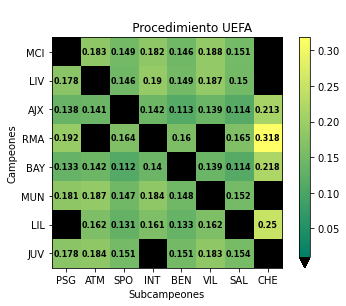

```python
plot_mat(mat_uefa,minimo=0.01,fontsize=8,title= '''
             Procedimiento UEFA''')
```

### 2.2 Sorteo Alternativo a la UEFA

```python
#Definimos la función que realiza el sorteo como lo hace la UEFA,
#dada una permutación para el orden en que se eligen los subcampeones.
def sorteo(perm):
#     print('Permutacion: ', perm)
    #Creamos una lista donde guardaremos los partidos
    torneo = []

    #Creamos la matriz de partidos válidos, que vale 1 si un partido es
    #válido y 0 sino.

    mat = matriz_validos()
#     print('matriz_validos: ',mat)


    #Agarramos todos los 4781 torneos válidos
    validos = torneos_validos.copy()

    #Iteramos sobre las permutaciones, lo cual corresponde con ir
    # eligiendo los subcampeones al azar.
    for num in perm:
#         print('Subcampeon: ', num)

        while True:
            #Elegimos un campeón que pueda jugar contra nuestro
            # subcampeón usando la función "elegir_campeon".

            campeon = elegir_campeon(mat,num)
            #Creamos el partido
            part = (campeon,num)

            #Reducimos la lista de torneos válidos a aquéllos que incluyen
            #también a este partido
            nuevo = encontrar_validos(validos,part)
#             print('len nuevos', len(nuevo))

            #Si no hay torneos válidos que lo tengan, se repite esta sección
            # Si sí hay, se para esta sección y se sigue.
            if nuevo != False:
                break
#         print('partido: ',part)


        #Agregamos el partido a la lista
        torneo.append(part)
#         print('Torneo hasta ahora: ', torneo)

        #Actualizamos la lista de torneos válidos.
        validos = nuevo

        #Actualizamos la matriz, poniendo ceros en las filas y columnas
        #correspondientes a equipos que ya tienen seleccionado un partido.
        mat.T[num] = [0,0,0,0,0,0,0,0]
        mat[campeon] = [0,0,0,0,0,0,0,0]
        #Ponemos un 1 en el partido que fue seleccionado.
        mat[campeon,num] = 1

#         print('matriz de part', mat)
        #Si ya sólo hay una posibilidad para el torneo, la regresamos
        if len(nuevo) == 1:
            return(nuevo[0])

    #Regresamos el torneo
    return(torneo)
import random
def elegir_campeon(mat,num):
    posibles_campeones = np.where(mat.T[num]==1)[0]

    pesos = []
    for i in posibles_campeones:
        pesos.append(1/mat_uefa[i][num])


#     print('posibles campeones: ', posibles_campeones)
#     print('pesos: ',pesos)
    #Elegimos uno
    campeon_elegido = random.choices(posibles_campeones,weights=pesos,
                                    k=1)[0]

#     print('campeon: ', campeon_elegido)
    return(campeon_elegido)

def encontrar_validos(validos,part):
    nuevo = []
    for res in validos:
        if part in res:
            nuevo.append(res)
    if len(nuevo) > 0:
        return(nuevo)
    else:
        return(False)
```

```python
#### Toma 4 o 5 min

# Ahora hacemos el sorteo para todas las permutaciones posibles

#En mat_uefa vamos a guardar las probabilidades de cada partido.
mat_uefa_mod = np.zeros((8,8))

#Contamos el número de torneos que vamos creando
iteraciones = 0
#permutaciones guarda las permutaciones posibles
permutaciones = list(itertools.permutations(range(8)))

# Lo vamos a repetir 1 vez para todas las permutaciones
for j in range(1):
    for perm in permutaciones:
        iteraciones += 1
        tor = sorteo(perm)

        for partido in tor:
            mat_uefa_mod[partido[0]][partido[1]] += 1

mat_uefa_mod =mat_uefa_mod/iteraciones
#print(mat_uefa)
```

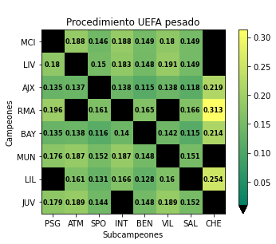

```python
plot_mat(mat_uefa_mod,minimo=0.01,fontsize=8,title= '''
Procedimiento UEFA pesado''')
```

### 2.3 Sorteo con uniformidad de torneos:

Vemos qué pasa si el sorteo se hace eligiendo con probabilidad uniforme alguno de los posibles torneos válidos.

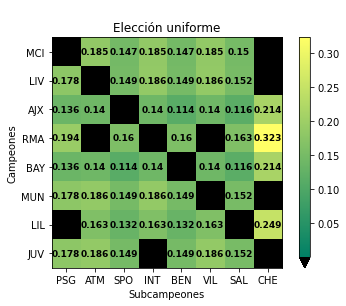

```python
# Vamos a crear la matriz de probabilidad para este caso:
mat_uniforme_torneos = np.zeros((8,8))

#Iteramos sobre cada uno de los torneos válidos
for tor in torneos_validos:
    # Para cada torneo, iteramos sobre los partidos.
    for partido in tor:
        i,j = partido
        #Vemos quienes son los equipos correspondientes a este partido.
        #le agregamos un poquito de probabilidad al partido en la matriz
        mat_uniforme_torneos[i][j] += 1/num_torneos
#La graficamos
plot_mat(mat_uniforme_torneos,redondeo=3,title = '''
Elección uniforme''')
```

## 3. Criterios para medir la equidad de una tabla de probabilidades

En esta sección definimos varios criterios que pueden usarse para medir qué tan equitativa es una tabla de probabilidades

```python
# Dada una matriz de probabilidades, la convertimos en un vector
# que solamente se queda con las probabilidades mayores que 0
# (es decir, omite los partidos imposibles)
def vectorizar(mat):
    'Convertir una matriz mat en un vector con solamente las entradas >0'
    vec = [j for j in mat.flatten() if j > 1e-8]
    return(vec)


#Función para convertir un vector en una matriz de probabilidades,
#poniendo 0s en las posiciones en las que hay partidos imposibles.
def matrificar(vec):
    '''Convertir un vector en una tabla de probabilidades,
    poniendo 0s en los partidos que no son válidos'''
    mat = matriz_validos()

    k = 0
    for i in range(len(mat)):
        for j in range(len(mat)):
            if mat[i][j] == 1:
                mat[i][j] = vec[k]
                k += 1

    return(mat)
```

###### Definimos los criterios:

```python
'Criterio que suma las varianzas de cada columna y fila'
def criterio_suma_varianzas(vec,normal=1):
    'Suma las varianzas de cada columna y cada renglón'
    mat = matrificar(vec)
    total = 0

    #sumamos sobre las filas
    for v in mat:
        v = [j for j in v if j >1e-8]
        total += np.var(v,ddof=1)

    #y ahora sobre las columnas
    for v in mat.T:
        v = [j for j in v if j >1e-8]
        total += np.var(v,ddof=1)
    return(total/normal)

mat_u = mat_uefa.copy()
vec_u = vectorizar(mat_u)
#Evaluamos el criterio en la matriz uniforme, que nos servirá para
#normalizar este criterio.
csv_u =  criterio_suma_varianzas(vec_u,1)


'''Criterio de la varianza total'''
def criterio_varianza_total(vec,normal = 1):
    'Calcula la varianza total de todos los datos de la tabla'
    return(np.var(vec,ddof=1)/normal)
cvt_u = criterio_varianza_total(vec_u,1)


'''Criterio del Rango'''
def criterio_rango(vec,normal=1):
    'Calcula el rango en los datos de la tabla.'
    return((np.max(vec)-np.min(vec))/normal)
cr_u = criterio_rango(vec_u,1)

'''Criterio del Máximo'''
def criterio_max(vec,normal=1):
    'Regresa el elemento máximo de la lista'
    return(max(vec)/normal)
cm_u = criterio_max(vec_u,1)


'''Criterio de Gini'''
def criterio_gini(vec,normal=1):
    total = 0
    for i, xi in enumerate(vec[:-1], 1):
        total += np.sum(np.abs(xi - vec[i:]))
    return ((total / (len(vec)**2 * np.mean(vec))/normal))
cg_u = criterio_gini(vec_u,1)


'''Criterio de canberra'''
def criterio_canberra(vec,normal = 1):
    q = np.mean(vec)
    tot = 0
    for a in vec:
        tot += np.abs(a-q)/(a+q)
    return(tot/normal)
cc_u = criterio_canberra(vec_u,1)


'''Criterio de Atkinson'''
def criterio_atkinson(vec, normal = 1):
    return(ineq.atkinson.index(vec)/normal)
ca_u = criterio_atkinson(vec_u,1)


'''Criterio de Theil'''
def criterio_theil(vec,normal=1):
    total = 0
    N = len(vec)
    mu = np.mean(vec)
    for i in range(N):
        total += vec[i]/mu * np.log(vec[i]/mu)
    return((total/N)/normal)
ct_u = criterio_theil(vec_u,1)



def criterio_suma(vec, normal=1):
    suma = (criterio_suma_varianzas(vec,csv_u)+
            criterio_varianza_total(vec,cvt_u)+
            criterio_rango(vec,cr_u) + criterio_max(vec,cm_u)+
            criterio_gini(vec,cg_u) + criterio_canberra(vec,cc_u)+
            criterio_atkinson(vec,ca_u) +
            criterio_theil(vec,ct_u))/normal
    return(suma)
cs_u = criterio_suma(vec_u,1)



lista_criterios = [criterio_suma_varianzas,criterio_varianza_total,
                  criterio_rango,criterio_max,
                  criterio_gini,criterio_theil,
                   criterio_atkinson]
#                   criterio_dif]
#                    criterio_suma]
nombres_criterios = ['Suma de varianzas','Varianza total','Rango',
                    'Máximo','Gini', 'Theil','Atkinson']
#                      'Diferencia de promedio máximos y mínimos']
#                      'Suma']




# c_ut = [csv_u,cvt_u,cr_u,cm_u,cg_u,cc_u,ca_u,ct_u,cd_u,cs_u]
```

```python
# Función que evalua todos los criterios dado un vector
def evaluar_todos(vec):
    res = []

    for crit in lista_criterios:
        res.append(crit(vec))
    return(res)
```

##### Calculamos los criterios sobre la tabla de probabilidades de la UEFA

```python
res_uefa = evaluar_todos(vec_u)

columnas = nombres_criterios
df = pd.DataFrame(columns=columnas)
for i in range(len(columnas)):
    c = columnas[i]
    df.at[0,c] = res_uefa[i]

df =df.style.hide_index()

df
```

| Suma de varianzas | Varianza total | Rango | Máximo | Gini | Theil | Atkinson |
| --- | --- | --- | --- | --- | --- | --- |
| 0.015626 | 0.001295 | 0.206672 | 0.318378 | 0.109266 | 0.021709 | 0.010466 |

#### Sobre el metodo UEFA modificado

```python
res_uefa_mod = evaluar_todos(vectorizar(mat_uefa_mod))

columnas = nombres_criterios
df = pd.DataFrame(columns=columnas)
for i in range(len(columnas)):
    c = columnas[i]
    df.at[0,c] = res_uefa_mod[i]
df =df.style.hide_index()

df
```

| Suma de varianzas | Varianza total | Rango | Máximo | Gini | Theil | Atkinson |
| --- | --- | --- | --- | --- | --- | --- |
| 0.015444 | 0.001293 | 0.197892 | 0.312723 | 0.110801 | 0.021755 | 0.010492 |

##### Y sobre la Uniforme

```python
res_uniforme = evaluar_todos(vectorizar(mat_uniforme_torneos))
columnas = nombres_criterios
df = pd.DataFrame(columns=columnas)
for i in range(len(columnas)):
    c = columnas[i]
    df.at[0,c] = res_uniforme[i]

df =df.style.hide_index()

df
```

| Suma de varianzas | Varianza total | Rango | Máximo | Gini | Theil | Atkinson |
| --- | --- | --- | --- | --- | --- | --- |
| 0.016060 | 0.001304 | 0.209580 | 0.323154 | 0.108255 | 0.021686 | 0.010418 |

# 4. Encontrar matrices que optimizan un criterio.

Definimos el procedimiento para dado un criterio, encontrar la tabla de probabilidades que sea válida y que minimiza al criterio.

```python
#Definimos funciones que darán las condiciones que debe de cumplir la
# tabla de probabilidades

#Primero guardamos la lista de partidos validos en p_vals
p_vals = partidos_validos()
# print(len(p_vals))

#Luego, una condición es que la suma de cada columna debe de valer 1.
def suma_cols(vec):
    ar = np.ones(8)

    #Iteramos sobre los partidos validos
    for i in range(len(p_vals)):
        #definimos el i-esimo partido, llamado par
        par = p_vals[i]
        #ar va a ser un array de 8 elementos, 1-col[i] en cada uno
        ar[par[1]]-= vec[i]
    return(ar)

#Luego, la suma de cada fila debe de ser 1.
def suma_filas(vec):
    ar = np.ones(8)
    for i in range(len(p_vals)):
        par = p_vals[i]
        ar[par[0]] -= vec[i]
    return(ar)

#Además, una función que devuelve al propio vector, cuyos elementos tienen
# que ser mayor o iguales que 0.
def todos_mayor_que_0(vec):
    return(np.array(vec)-np.ones(len(vec))*0.0005)

#Entonces, éstas son las condiciones que debe de cumplir la tabla.
ineq_cons = {'type': 'ineq',
            'fun': todos_mayor_que_0}
eq_cons = {'type': 'eq',
          'fun': suma_cols}
eq_cons1 = {'type': 'eq',
          'fun': suma_filas}
```

```python
from scipy.optimize import Bounds
bo = Bounds([0]*int(np.sum(matriz_validos())),
           [1]*int(np.sum(matriz_validos())))

#Dado un criterio, encontrar la tabla que lo minimiza
def encontrar_minimo(crit,ftol = [1e-6,1e-8,1e-25],
                     eps=[1e-8,1e-9,1e-11],
                     maxiter=[100,200,1000],
                    x0s =  [vectorizar(mat_uniforme_torneos)],b=bo):

    #nuestro intento inicial va a ser la matriz uniforme
    mejor_mat = 0
    mejor_res = np.inf
    mejor_sum = np.inf
    for x0 in x0s:
        for ep in eps:
            for it in maxiter:
                for ft in ftol:


                    #Luego, minimizamos el criterio
                    res = minimize(crit,x0,method="SLSQP",
                       constraints=[eq_cons,eq_cons1], bounds= b
                       ,options={'maxiter':it,'ftol':ft,'eps':ep})

#                 print(ep,ft,it,res['fun'])


#                     if res['fun']+criterio_suma(res['x']) < mejor_res+mejor_sum:
                    if res['fun'] < mejor_res:
                        mejor_res = res['fun']
                        mejor_mat = res
                        mejor_eps = ep
                        mejor_ftol = ft
                        mejor_iter = it
                        mejor_sum = criterio_suma(res['x'],)


#     print(mejor_eps,mejor_ftol,mejor_iter)
    return(matrificar(mejor_mat['x']))
```

Para cada criterio, encontraremos la matriz que lo minimiza y le calcularemos su valor en los otros criterios

```python
#Función que dada la matriz de probabilidades, la descompone con el
# teorema de Birkhoff y encuentra así los torneos y sus probabilidades
# que se deben de usar para tener esas probabilidades de partidos
def encontrar_torneos(mat):

    result=birkhoff.birkhoff_von_neumann_decomposition(mat)
    coefs = []
    perms = []
    for coefficient, permutation_matrix in result:
        print('coefficient:', coefficient)
        print('permutation matrix:\n', permutation_matrix)
        coefs.append(coefficient)
        perms.append(permutation_matrix)
    return(coefs,perms)
```

##### Criterio de Suma de varianzas

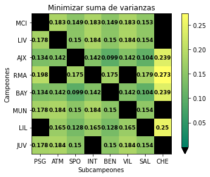

```python
mat_csv = encontrar_minimo(criterio_suma_varianzas)
plot_mat(mat_csv,title='Minimizar suma de varianzas')
```

```python
res_csv = evaluar_todos(vectorizar(mat_csv))
res_csv_n = [res_csv[i]/res_uefa[i] for i in range(len(res_csv))]
print(res_csv)
print(res_csv_n)

columnas = nombres_criterios
df = pd.DataFrame(columns=columnas)
for i in range(len(columnas)):
    c = columnas[i]
    df.at[0,c] = res_csv[i]

df =df.style.hide_index()

df
```

```
[0.013394641948603394, 0.001280117553391994, 0.1739390474181033, 0.2729738056478645, 0.11484563961295025, 0.022809992052670584, 0.011313267632286572]
[0.8571755603012834, 0.9887738192169998, 0.8416203518418246, 0.8573890974310117, 1.0510618205214055, 1.0507141346328561, 1.0809700710881778]
```

| Suma de varianzas | Varianza total | Rango | Máximo | Gini | Theil | Atkinson |
| --- | --- | --- | --- | --- | --- | --- |
| 0.013395 | 0.001280 | 0.173939 | 0.272974 | 0.114846 | 0.022810 | 0.011313 |

```python
encontrar_torneos(mat_csv)
```

```
coefficient: 0.14152627000572632
permutation matrix:
 [[0. 1. 0. 0. 0. 0. 0. 0.]
 [1. 0. 0. 0. 0. 0. 0. 0.]
 [0. 0. 0. 1. 0. 0. 0. 0.]
 [0. 0. 1. 0. 0. 0. 0. 0.]
 [0. 0. 0. 0. 0. 1. 0. 0.]
 [0. 0. 0. 0. 1. 0. 0. 0.]
 [0. 0. 0. 0. 0. 0. 0. 1.]
 [0. 0. 0. 0. 0. 0. 1. 0.]]
coefficient: 0.03625919803053121
permutation matrix:
 [[0. 1. 0. 0. 0. 0. 0. 0.]
 [1. 0. 0. 0. 0. 0. 0. 0.]
 [0. 0. 0. 0. 1. 0. 0. 0.]
 [0. 0. 0. 0. 0. 0. 0. 1.]
 [0. 0. 0. 1. 0. 0. 0. 0.]
 [0. 0. 0. 0. 0. 0. 1. 0.]
 [0. 0. 0. 0. 0. 1. 0. 0.]
 [0. 0. 1. 0. 0. 0. 0. 0.]]
coefficient: 0.005607971150504154
permutation matrix:
 [[0. 1. 0. 0. 0. 0. 0. 0.]
 [0. 0. 1. 0. 0. 0. 0. 0.]
 [0. 0. 0. 0. 0. 0. 0. 1.]
 [0. 0. 0. 0. 1. 0. 0. 0.]
 [0. 0. 0. 1. 0. 0. 0. 0.]
 [0. 0. 0. 0. 0. 0. 1. 0.]
 [0. 0. 0. 0. 0. 1. 0. 0.]
 [1. 0. 0. 0. 0. 0. 0. 0.]]
coefficient: 0.11197102582812277
permutation matrix:
 [[0. 0. 1. 0. 0. 0. 0. 0.]
 [0. 0. 0. 1. 0. 0. 0. 0.]
 [0. 0. 0. 0. 0. 0. 0. 1.]
 [0. 0. 0. 0. 1. 0. 0. 0.]
 [0. 1. 0. 0. 0. 0. 0. 0.]
 [0. 0. 0. 0. 0. 0. 1. 0.]
 [0. 0. 0. 0. 0. 1. 0. 0.]
 [1. 0. 0. 0. 0. 0. 0. 0.]]
```

[output cut: 295 more lines]

```
 [0. 0. 0. 0. 0. 0. 0. 1.]
 [1. 0. 0. 0. 0. 0. 0. 0.]
 [0. 1. 0. 0. 0. 0. 0. 0.]
 [0. 0. 0. 1. 0. 0. 0. 0.]
 [0. 0. 1. 0. 0. 0. 0. 0.]]
coefficient: 0.03356201382258067
permutation matrix:
 [[0. 0. 0. 0. 0. 0. 1. 0.]
 [0. 0. 0. 0. 1. 0. 0. 0.]
 [0. 0. 0. 0. 0. 1. 0. 0.]
 [0. 0. 1. 0. 0. 0. 0. 0.]
 [0. 0. 0. 0. 0. 0. 0. 1.]
 [1. 0. 0. 0. 0. 0. 0. 0.]
 [0. 0. 0. 1. 0. 0. 0. 0.]
 [0. 1. 0. 0. 0. 0. 0. 0.]]
```

```
([0.14152627000572632,
  0.03625919803053121,
  0.005607971150504154,
  0.11197102582812277,
  0.0108018081249249,
  0.018753433877537612,
  3.2660633364489655e-09,
  0.007044614195773902,
  0.020909432289665075,
  0.10629417287867118,
  0.008204883369665184,
  0.008714698248440678,
  0.014535770877189352,
  0.0015101192472770086,
  0.023224355590907103,
  0.014145903005361865,
  0.020502275480969112,
  0.0012379465176876603,
  0.04561860950902588,
  0.014587866815260336,
  0.02459259142090084,
  0.0826933035350168,
  0.016964643473414254,
  0.010892748070271074,
  2.830379883667078e-05,
  0.00234962546421566,
  0.010546952870167992,
  0.042741901971424856,
  0.02194632346597511,
  0.05049950085159746,
  0.013103727869277937,
  0.029929334044085876,
  0.012276059914166804,
  0.036422611118763215,
  0.03356201382258067],
 [array([[0., 1., 0., 0., 0., 0., 0., 0.],
         [1., 0., 0., 0., 0., 0., 0., 0.],
         [0., 0., 0., 1., 0., 0., 0., 0.],
         [0., 0., 1., 0., 0., 0., 0., 0.],
         [0., 0., 0., 0., 0., 1., 0., 0.],
```

[output cut: 260 more lines]

```
         [0., 0., 0., 0., 1., 0., 0., 0.],
         [0., 0., 0., 0., 0., 1., 0., 0.],
         [0., 0., 0., 0., 0., 0., 0., 1.],
         [1., 0., 0., 0., 0., 0., 0., 0.],
         [0., 1., 0., 0., 0., 0., 0., 0.],
         [0., 0., 0., 1., 0., 0., 0., 0.],
         [0., 0., 1., 0., 0., 0., 0., 0.]]),
  array([[0., 0., 0., 0., 0., 0., 1., 0.],
         [0., 0., 0., 0., 1., 0., 0., 0.],
         [0., 0., 0., 0., 0., 1., 0., 0.],
         [0., 0., 1., 0., 0., 0., 0., 0.],
         [0., 0., 0., 0., 0., 0., 0., 1.],
         [1., 0., 0., 0., 0., 0., 0., 0.],
         [0., 0., 0., 1., 0., 0., 0., 0.],
         [0., 1., 0., 0., 0., 0., 0., 0.]])])
```

##### Criterio de varianza total

```
[[0.         0.18443074 0.14809305 0.18438484 0.14787019 0.18396839
  0.15125279 0.        ]
 [0.17797651 0.         0.14957907 0.18503286 0.14915001 0.18485449
  0.15340705 0.        ]
 [0.13355237 0.14049974 0.         0.14098838 0.10585636 0.14102883
  0.1091152  0.22895912]
 [0.19724794 0.         0.16909814 0.         0.16947689 0.
  0.17220914 0.29196789]
 [0.13453675 0.14115124 0.10541186 0.14104626 0.         0.14112451
  0.10873757 0.22799181]
 [0.17823098 0.18510622 0.1495871  0.18486773 0.14953463 0.
  0.15267333 0.        ]
 [0.         0.16406867 0.12867646 0.16367993 0.12847873 0.16401503
  0.         0.25108118]
 [0.17845546 0.18474338 0.14955432 0.         0.14963319 0.18500873
  0.15260492 0.        ]]
```

[figure not shown]

```python
mat_cvt = encontrar_minimo(criterio_varianza_total)
plot_mat(mat_cvt,title='Minimizar varianza total')
```

```python
res_cvt = evaluar_todos(vectorizar(mat_cvt))
res_cvt_n = [res_cvt[i]/res_uefa[i] for i in range(len(res_cvt))]
print(res_cvt)
print(res_cvt_n)

columnas = nombres_criterios
df = pd.DataFrame(columns=columnas)
for i in range(len(columnas)):
    c = columnas[i]
    df.at[0,c] = res_cvt[i]

df =df.style.hide_index()

df
```

[output not shown]

[output not shown]

```python
encontrar_torneos(mat_cvt)
```

##### Criterio de max

```
[[0.         0.19094402 0.12169541 0.1711414  0.17295829 0.17768539
  0.16557549 0.        ]
 [0.184843   0.         0.16348414 0.1508694  0.16585087 0.16760899
  0.1673436  0.        ]
 [0.13053729 0.14892527 0.         0.12924956 0.08036638 0.16801455
  0.09290695 0.25      ]
 [0.20568475 0.         0.17584356 0.         0.17966908 0.
  0.1888026  0.25      ]
 [0.14267624 0.12790052 0.0937054  0.1531087  0.         0.1500716
  0.08253755 0.25      ]
 [0.17008146 0.21458731 0.13012922 0.21252798 0.12495539 0.
  0.14771865 0.        ]
 [0.         0.12762055 0.1595265  0.18310296 0.12868676 0.15106322
  0.         0.25      ]
 [0.16617725 0.19002233 0.15561575 0.         0.14751324 0.18555626
  0.15511516 0.        ]]
```

[figure not shown]

```python
mat_cm = encontrar_minimo(criterio_max)
plot_mat(mat_cm,'Minimizar el máximo')
```

```python
res_cm = evaluar_todos(vectorizar(mat_cm))
res_cm_n = [res_cm[i]/res_uefa[i] for i in range(len(res_cm))]
print(res_cm)
print(res_cm_n)

columnas = nombres_criterios
df = pd.DataFrame(columns=columnas)
for i in range(len(columnas)):
    c = columnas[i]
    df.at[0,c] = res_cm[i]

df =df.style.hide_index()

df
```

[output not shown]

[output not shown]

```python
encontrar_torneos(mat_cm)
```

##### Criterio de minimizar el rango

```
[[0.         0.21141381 0.12629698 0.17260383 0.13490073 0.20351156
  0.15127309 0.        ]
 [0.16507767 0.         0.15108484 0.19473929 0.15956951 0.20422916
  0.12529952 0.        ]
 [0.12496504 0.12496395 0.         0.12496349 0.12496349 0.12497307
  0.12517122 0.24999974]
 [0.19342328 0.         0.16376995 0.         0.18797838 0.
  0.20482831 0.25000007]
 [0.12497419 0.12496658 0.12497894 0.12496349 0.         0.12513367
  0.12498305 0.25000008]
 [0.18487892 0.18695433 0.12593812 0.22201662 0.136762   0.
  0.14345002 0.        ]
 [0.         0.17967237 0.12520697 0.16071328 0.12498026 0.15942703
  0.         0.2500001 ]
 [0.2066809  0.17202897 0.18272421 0.         0.13084563 0.18272552
  0.12499478 0.        ]]
```

[figure not shown]

```python
mat_cr = encontrar_minimo(criterio_rango)
plot_mat(mat_cr,'Minimizar el rango')
```

```python
res_cr = evaluar_todos(vectorizar(mat_cr))
res_cr_n = [res_cr[i]/res_uefa[i] for i in range(len(res_cr)-1)]
print(res_cr)
print(res_cr_n)

columnas = nombres_criterios
df = pd.DataFrame(columns=columnas)
for i in range(len(columnas)):
    c = columnas[i]
    df.at[0,c] = res_cr[i]

df =df.style.hide_index()

df
```

[output not shown]

| Suma de varianzas | Varianza total | Rango | Máximo | Gini | Theil | Atkinson |
| --- | --- | --- | --- | --- | --- | --- |
| 0.019285 | 0.001603 | 0.125037 | 0.250000 | 0.132604 | 0.028288 | 0.013902 |

```python
encontrar_torneos(mat_cr)
```

##### Criterio de minimizar Gini

```
[[0.         0.17310599 0.16022741 0.17310579 0.16022741 0.17310582
  0.16022758 0.        ]
 [0.17310586 0.         0.16022748 0.17310593 0.16022738 0.17310587
  0.16022748 0.        ]
 [0.1602274  0.16022739 0.         0.16022741 0.07797167 0.16022745
  0.10801291 0.17310578]
 [0.16022753 0.         0.14055821 0.         0.14055991 0.
  0.14306722 0.41558713]
 [0.16022741 0.16022735 0.07797455 0.16022743 0.         0.16022741
  0.10800996 0.17310589]
 [0.17310586 0.1731059  0.16022739 0.17310603 0.16022739 0.
  0.16022742 0.        ]
 [0.         0.16022744 0.14055758 0.16022742 0.14055885 0.1602275
  0.         0.23820121]
 [0.17310594 0.17310593 0.16022737 0.         0.16022739 0.17310595
  0.16022742 0.        ]]
```

[figure not shown]

```python
mat_cg = encontrar_minimo(criterio_gini)
plot_mat(mat_cg,'Minimizar el criterio de gini')
```

```python
res_cg = evaluar_todos(vectorizar(mat_cg))
res_cg_n = [res_cg[i]/res_uefa[i] for i in range(len(res_cg))]
print(res_cg)
print(res_cg_n)


columnas = nombres_criterios
df = pd.DataFrame(columns=columnas)
for i in range(len(columnas)):
    c = columnas[i]
    df.at[0,c] = res_cg[i]

df =df.style.hide_index()

df
```

[output not shown]

[output not shown]

```python
encontrar_torneos(mat_cg)
```

##### Minimizar Theil

```
[[0.         0.18460245 0.1478369  0.18460245 0.1478369  0.18460245
  0.15051886 0.        ]
 [0.17851254 0.         0.14894104 0.18598117 0.14894104 0.18598118
  0.15164303 0.        ]
 [0.1347573  0.1403953  0.         0.14039531 0.11243408 0.1403953
  0.11447378 0.21714893]
 [0.19494779 0.         0.16265371 0.         0.16265371 0.
  0.16560447 0.31414033]
 [0.1347573  0.14039531 0.11243408 0.1403953  0.         0.1403953
  0.11447379 0.21714892]
 [0.17851254 0.18598117 0.14894104 0.18598117 0.14894104 0.
  0.15164304 0.        ]
 [0.         0.1626446  0.13025219 0.1626446  0.13025219 0.16264459
  0.         0.25156182]
 [0.17851254 0.18598117 0.14894104 0.         0.14894104 0.18598117
  0.15164303 0.        ]]
```

[figure not shown]

```python
mat_ct = encontrar_minimo(criterio_theil)
plot_mat(mat_ct,'Minizar criterio de Theil')
```

```python
res_ct = evaluar_todos(vectorizar(mat_ct))
res_ct_n = [res_ct[i]/res_uefa[i] for i in range(len(res_ct))]
print(res_ct)
print(res_ct_n)

columnas = nombres_criterios
df = pd.DataFrame(columns=columnas)
for i in range(len(columnas)):
    c = columnas[i]
    df.at[0,c] = res_ct[i]

df =df.style.hide_index()

df
```

[output not shown]

[output not shown]

```python
encontrar_torneos(mat_ct)
```

##### Minimizar Atkinson

```
[[0.         0.18473212 0.14778723 0.1847321  0.14778721 0.18473215
  0.15022918 0.        ]
 [0.1788264  0.         0.14880164 0.1861507  0.14880166 0.18615073
  0.15126887 0.        ]
 [0.13563462 0.14045377 0.         0.14045375 0.11546458 0.14045374
  0.11714853 0.21039101]
 [0.19225162 0.         0.15894237 0.         0.15894236 0.
  0.16166719 0.32819646]
 [0.13563462 0.14045376 0.11546456 0.14045375 0.         0.14045377
  0.11714853 0.21039101]
 [0.17882635 0.18615073 0.14880167 0.18615076 0.14880164 0.
  0.15126885 0.        ]
 [0.         0.1620589  0.13140085 0.16205894 0.13140088 0.16205891
  0.         0.25102152]
 [0.17882638 0.18615072 0.14880168 0.         0.14880167 0.1861507
  0.15126885 0.        ]]
```

[figure not shown]

```python
mat_ca = encontrar_minimo(criterio_atkinson)
plot_mat(mat_ca,'Minimizar el criterio de Atkinson')
```

```python
res_ca = evaluar_todos(vectorizar(mat_ca))
res_ca_n = [res_ca[i]/res_uefa[i] for i in range(len(res_ca))]
print(res_ca)
print(res_ca_n)

columnas = nombres_criterios
df = pd.DataFrame(columns=columnas)
for i in range(len(columnas)):
    c = columnas[i]
    df.at[0,c] = res_ca[i]

df =df.style.hide_index()

df
```

[output not shown]

[output not shown]

```python
encontrar_torneos(mat_ca)
```

[output not shown]

# 5. Método con un parámetro Libre

### Otras varianzas

Probamos la minimización pero ahora usando varianzas ligeramente distintas que dependen de un parámetro libre

[output not shown]

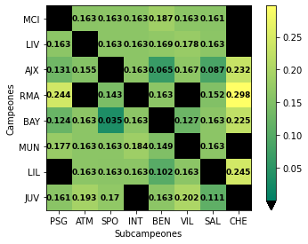

[output not shown]

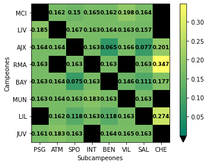

```
0.2824372716321497
0.75
```

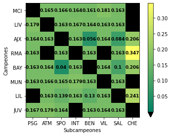

```
0.30758595266315236
1.0
```

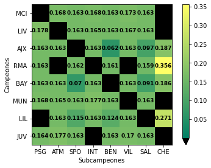

```
0.29347451177478295
1.25
```

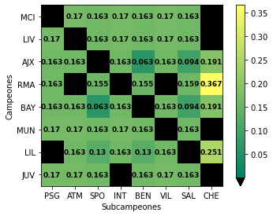

```
0.30355807287667186
1.5
```

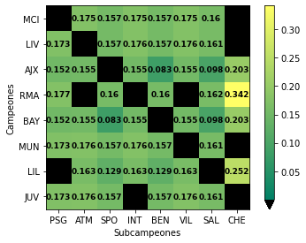

```
0.25868596658821447
1.75
```

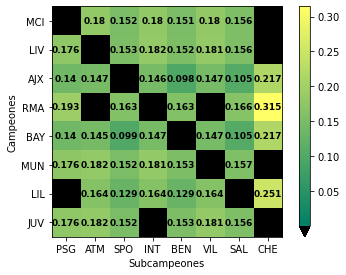

```
0.2165906059375966
2.0
```

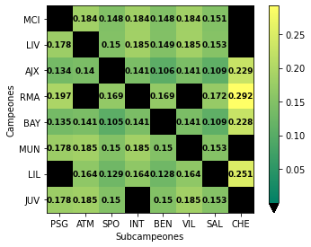

```
0.18655603363041062
2.25
```

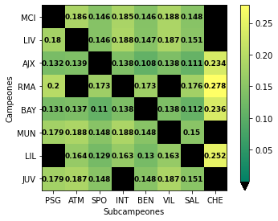

```
0.16995742549399406
2.5
```

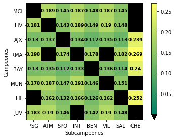

```
0.1574346005150476
2.75
```

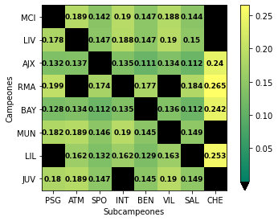

```
0.15456949582904367
3.0
```

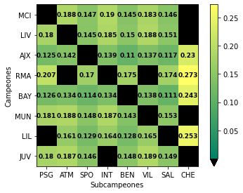

```
0.16347562979329675
3.25
```

[17 more figures not shown]

```
0.20929725548974476
```

```python
%matplotlib inline
lista = []
# sumaa = []
for al in np.arange(1,5,0.25):

    print(al)

    def criterio_nuevo(vec):
        prom = np.mean(vec)
        vec = np.abs(vec - prom)**al
        return(np.sum(vec)/(len(vec)-1))
    a=encontrar_minimo(criterio_nuevo)
    plot_mat(a)
    plt.show()

    res = criterio_rango(vectorizar(a))
#     res_n = [res[i]/res_uefa[i] for i in range(len(res_uefa))]
#     suma = np.sum(res_n)

    print(res)
#     print(suma)
    lista.append(res)
#     sumaa.append(suma)
```

[figure not shown]

```python
plt.plot(np.arange(1,5,0.25),lista)
plt.xlabel('Valor del exponente en la varianza')
plt.ylabel('Rango obtenido')
plt.title('Rango vs exponente de la varianza que se minimiza')
```

[figure not shown]

```python
# Poner aqui el valor de al que es minimo (aprox)

al = 2.75

def criterio_nuevo(vec):
        prom = np.mean(vec)
        vec = np.abs(vec - prom)**al
        return(np.sum(vec)/(len(vec)-1))
mat_al=encontrar_minimo(criterio_nuevo)

plot_mat(mat_al,title='Minimizar la varianza con alpha = ' + str(al))
plt.show()
```

```python
res_al = evaluar_todos(vectorizar(mat_al))
res_al_n = [res_al[i]/res_uefa[i] for i in range(len(res_al))]
print(res_al)

columnas = nombres_criterios
df = pd.DataFrame(columns=columnas)
for i in range(len(columnas)):
    c = columnas[i]
    df.at[0,c] = res_al[i]

df =df.style.hide_index()

df
```

```
[0.013929997140227777, 0.0013056175157258214, 0.15456949582904367, 0.26538426044619684, 0.11843195535296366, 0.022945572710034, 0.011272159377996305]
```

| Suma de varianzas | Varianza total | Rango | Máximo | Gini | Theil | Atkinson |
| --- | --- | --- | --- | --- | --- | --- |
| 0.013930 | 0.001306 | 0.154569 | 0.265384 | 0.118432 | 0.022946 | 0.011272 |